# Análisis general: distribución de ingresos para la población de Cali, Valle del Cauca

Proyecto de movilidad

2022-11-11

# Método de imputación sobre los ingresos corrientes en la Gran Encuestra Integrada de Hogares (GEIH) 2022

La metodología de imputación corresponde a la imputación múltiple mediante ecuaciones encadenadas. En general, se derivan cinco bases de datos imputadas a partir de 50 iteraciones. La **Tabla 1** presenta las imputaciones múltiples diferenciadas según la base de datos imputada; la **Tabla 2** presenta, por razones expositivas, una base de datos seleccionada, entre las cinco resultantes, de manera arbitraria.

Tabla 1: Imputación de ingresos corrientes para los individuos diferenciada según la base de datos. Método: imputación múltiple por ecuaciones encadenadas

|  | 1 | 2 | 3 | 4 | 5 |
| --- | --- | --- | --- | --- | --- |
| 35 | 1000000 | 5000000 | 5000000 | 1000000 | 1400000 |
| 48 | 3000000 | 0 | 5000000 | 1000000 | 1400000 |
| 112 | 800000 | 870000 | 5400000 | 1085000 | 80000 |
| 305 | 1100000 | 870000 | 5400000 | 1085000 | 3000000 |
| 329 | 1200000 | 1000000 | 2000000 | 5142000 | 3000000 |
| 419 | 1200000 | 5000000 | 5400000 | 1085000 | 3000000 |
| 552 | 800000 | 0 | 5000000 | 1085000 | 2700000 |
| 592 | 1200000 | 870000 | 2000000 | 1000000 | 1400000 |
| 671 | 1000000 | 870000 | 5400000 | 1000000 | 80000 |
| 742 | 1000000 | 1000000 | 2000000 | 5142000 | 1500000 |
| 832 | 1000000 | 0 | 1175000 | 5142000 | 1500000 |
| 854 | 800000 | 0 | 1175000 | 1000000 | 3000000 |
| 898 | 1200000 | 870000 | 5000000 | 720000 | 1400000 |
| 901 | 1200000 | 5000000 | 5000000 | 1085000 | 1400000 |
| 932 | 1000000 | 1000000 | 1034000 | 720000 | 1400000 |
| 933 | 1000000 | 1000000 | 2000000 | 1593000 | 1500000 |
| 934 | 1000000 | 5000000 | 5400000 | 1000000 | 1400000 |
| 948 | 800000 | 6500000 | 1175000 | 1593000 | 1400000 |
| 975 | 1100000 | 6500000 | 5000000 | 5142000 | 1400000 |
| 1002 | 3000000 | 6500000 | 5000000 | 5142000 | 3000000 |
| 1010 | 3000000 | 1000000 | 5400000 | 720000 | 80000 |
| 1027 | 1200000 | 1000000 | 1034000 | 720000 | 1500000 |
| 1062 | 1200000 | 5000000 | 5400000 | 1085000 | 1400000 |
| 1084 | 1000000 | 5000000 | 2000000 | 1000000 | 1500000 |
| 1089 | 800000 | 1000000 | 1034000 | 5142000 | 1500000 |
| 1094 | 1200000 | 1000000 | 2000000 | 1593000 | 80000 |
| 1153 | 1000000 | 1000000 | 5000000 | 5142000 | 1400000 |
| 1154 | 1100000 | 0 | 5400000 | 5142000 | 1400000 |
| 1207 | 1000000 | 5000000 | 2000000 | 1085000 | 80000 |
| 1223 | 1200000 | 1000000 | 5400000 | 1593000 | 3000000 |
| 1241 | 1000000 | 6500000 | 1175000 | 720000 | 80000 |
| 1242 | 1000000 | 870000 | 5400000 | 1593000 | 2700000 |
| 1262 | 800000 | 1000000 | 5000000 | 1000000 | 1400000 |
| 1295 | 1200000 | 5000000 | 1034000 | 5142000 | 2700000 |
| 1299 | 1200000 | 1000000 | 5400000 | 720000 | 1400000 |

Tabla 2: Bases de datos arbitraria imputada

| id | INGLABO |
| --- | --- |
| 7161143-1-2 | 4040000 |
| 7161145-1-1 | 1100000 |
| 7161145-1-2 | 1350000 |
| 7161146-1-1 | 1000000 |
| 7161146-1-4 | 1000000 |
| 7161152-1-1 | 500000 |
| 7161153-1-1 | 6000000 |
| 7161154-1-1 | 15000000 |
| 7161154-1-3 | 1520000 |
| 7161155-1-1 | 2622000 |

Con base en las cinco bases de datos imputadas y la base de datos sin imputar, la siguiente tabla presenta la clasificación por deciles sobre los ingresos corrientes de las personas:

Clasificación por deciles sobre los ingresos corrientes de las personas a partir de seis bases de datos (la base de datos original y cinco bases de datos imputados)

|  | Original | Imputada_1 | Imputada_2 | Imputada_3 | Imputada_4 | Imputada_5 |
| --- | --- | --- | --- | --- | --- | --- |
| 10% | 300000 | 300000 | 300000 | 300000 | 300000 | 300000 |
| 20% | 600000 | 600000 | 600000 | 600000 | 600000 | 600000 |
| 30% | 1000000 | 1000000 | 1000000 | 1000000 | 1000000 | 1000000 |
| 40% | 1000000 | 1000000 | 1000000 | 1000000 | 1000000 | 1000000 |
| 50% | 1100000 | 1100000 | 1092500 | 1100000 | 1100000 | 1100000 |
| 60% | 1200000 | 1200000 | 1200000 | 1246000 | 1200000 | 1250000 |
| 70% | 1500000 | 1500000 | 1500000 | 1500000 | 1500000 | 1500000 |
| 80% | 1894000 | 1838200 | 1900000 | 2000000 | 1900000 | 1900000 |
| 90% | 3005200 | 3000000 | 3500000 | 3500000 | 3327000 | 3000000 |

# Distribución de ingresos para la población de Cali, Valle del Cauca

En lo sucesivo, se presenta un análisis general sobre la distribución de ingresos corrientes para los hogares de Cali, Valle del Cauca. La fuente de información corresponde a los datos de la Gran Encuesta Integrada de Hogares (GEIH) para el período de septiembre/2022. Se considera que los ingresos corrientes de los hogares están contenidos en las siguientes variables: ingreso laboral (módulo de **Ocupados**); ingresos de personas no-ocupadas (módulo de **No-ocupados**); ingresos por arriendos, ingresos por jubilaciones o ingresos por pensión alimenticia de paternidad (módulo de **Otros ingresos**). La siguiente tabla presenta la información de ingresos diferenciados por hogares.

Ingresos corrientes y tamaño de los hogares de Cali, Valle del Cauca (septiembre/2022). Fuente: GEIH.

|  | ID Hogar | Ingreso corriente | Tamaño del hogar |
| --- | --- | --- | --- |
| 1 | 7161143-1 | 5000000 | 2 |
| 3 | 7161144-1 | 800000 | 2 |
| 5 | 7161145-1 | 3410000 | 2 |
| 7 | 7161146-1 | 2000000 | 4 |
| 11 | 7161152-1 | 2700000 | 2 |
| 13 | 7161153-1 | 6000000 | 2 |
| 15 | 7161154-1 | 16520000 | 3 |
| 18 | 7161155-1 | 3622000 | 4 |
| 22 | 7161156-1 | 21800000 | 4 |
| 26 | 7161159-1 | 960000 | 1 |

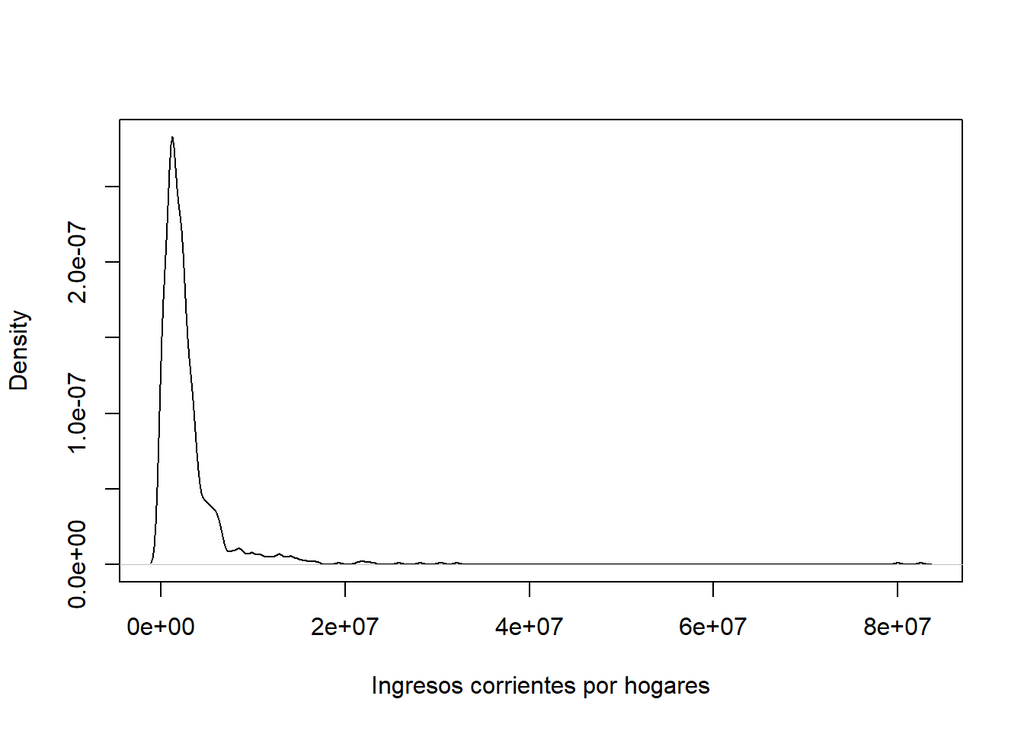

| Kurtosis | Skewness |
| --- | --- |
| 133.6261 | 9.350455 |

Ingresos corrientes para los hogares de Cali (septiembre/2022). Fuente: GEIH

| Kurtosis | Skewness |
| --- | --- |
| 133.6261 | 9.350455 |

| decil 1 | decil 2 | decil 3 | decil 4 | mediana | decil 6 | decil 7 | decil 8 | decil 9 | máx. | Media |
| --- | --- | --- | --- | --- | --- | --- | --- | --- | --- | --- |
| 259000 | 8e+05 | 1100000 | 1402000 | 1900000 | 2285200 | 2900000 | 3635600 | 5800000 | 82500000 | 2930268 |

La siguiente tabla presenta un contraste entre el tamaño y la distribución de los ingresos corrientes —clasificada en deciles— para los hogares de Cali en el período de septiembre/2022. Nótese que el ~87% de los hogares de Cali en la muestra se concentran en hogares unipersonales (~18%), hogares compuestos por dos (~27%), tres (~24%) y cuatro personas (~18%).Para el análisis subsiguiente se considera la composición de los hogares compuestos, principalmente, por dos, tres y cuatro personas.

Tamaño del hogar y deciles asociados a la distribución de los ingresos corrientes en los hogares de Cali (septiembre/2022). Fuente: GEIH

| Tamaño del hogar | decil 1 | decil 2 | decil 3 | decil 4 | decil 5 | decil 6 | decil 7 | decil 8 | decil 9 | decil 10 | Total |
| --- | --- | --- | --- | --- | --- | --- | --- | --- | --- | --- | --- |
| 1 | 15 | 34 | 34 | 15 | 22 | 8 | 8 | 10 | 8 | 7 | 161 |
| 2 | 5 | 30 | 25 | 20 | 25 | 36 | 25 | 31 | 26 | 20 | 243 |
| 3 | 7 | 17 | 27 | 23 | 23 | 21 | 38 | 19 | 18 | 27 | 220 |
| 4 | 4 | 12 | 12 | 21 | 15 | 16 | 18 | 18 | 22 | 25 | 163 |
| 5 | 0 | 5 | 1 | 7 | 4 | 10 | 6 | 8 | 11 | 4 | 56 |
| 6 | 0 | 1 | 1 | 2 | 9 | 1 | 3 | 3 | 9 | 5 | 34 |
| 7 | 0 | 0 | 1 | 0 | 1 | 1 | 3 | 1 | 2 | 5 | 14 |
| 8 | 0 | 0 | 0 | 1 | 0 | 0 | 1 | 1 | 1 | 2 | 6 |
| 9 | 0 | 0 | 0 | 0 | 0 | 0 | 0 | 0 | 0 | 1 | 1 |
| Total | 31 | 99 | 101 | 89 | 99 | 93 | 102 | 91 | 97 | 96 | 898 |

Composición para tres tamaños de hogares en Cali: hogares conformados por dos, tres y cuatro personas. Fuente: GEIH

| Grupo | Male (n = 2) | Female (n = 2) | Male (n = 3) | Female (n = 3) | Male (n = 4) | Female (n = 4) |
| --- | --- | --- | --- | --- | --- | --- |
| [1,4) | 1 | 1 | 13 | 10 | 11 | 14 |
| [14,19) | 9 | 8 | 27 | 23 | 34 | 41 |
| [19,31) | 45 | 50 | 60 | 80 | 52 | 66 |
| [31,51) | 69 | 90 | 93 | 107 | 82 | 108 |
| [4,9) | 4 | 9 | 18 | 15 | 19 | 28 |
| [51,70) | 63 | 87 | 64 | 77 | 48 | 61 |
| [70,Inf) | 32 | 47 | 20 | 26 | 10 | 23 |
| [9,14) | 7 | 7 | 15 | 23 | 30 | 29 |